# Lab 2

Lea Frank

1/20/2019

## 1. Write the code to load the data in directly from the web.

```r
df <- rio::import("https://github.com/fivethirtyeight/data/raw/master/alcohol-consumption/drinks.csv")
```

## 2. Explore the overall distribution of total alcohol consumed.

### Histogram

- play with number of bins
- settle on number of bins and provide brief justification in text

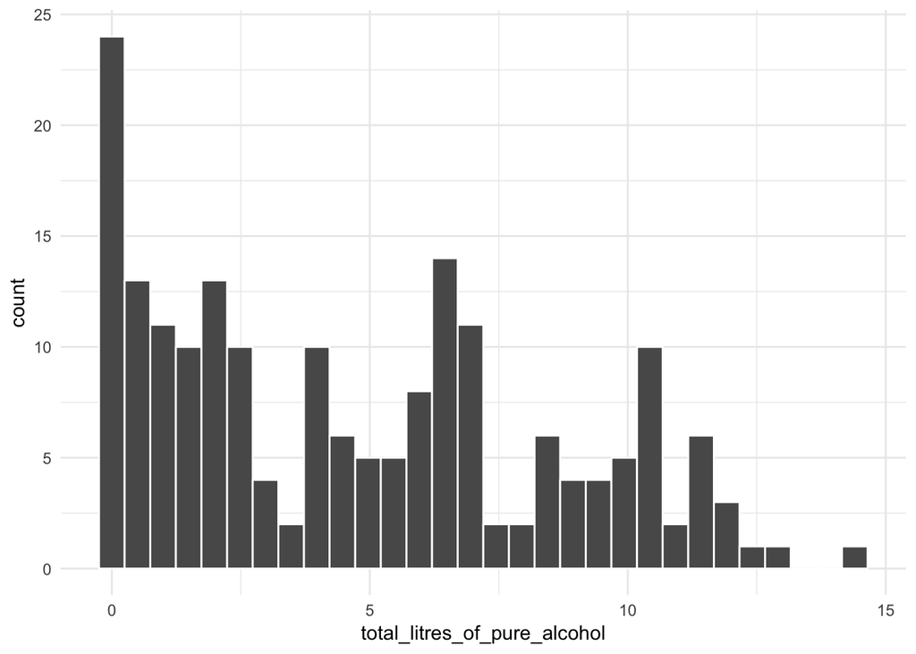

```r
ggplot(df, aes(x = total_litres_of_pure_alcohol)) +
  geom_histogram(color = "white") +
  theme_minimal()
```

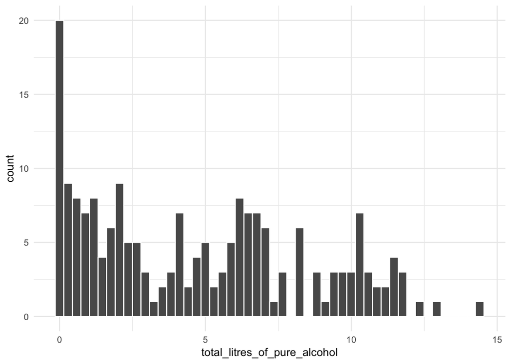

```r
ggplot(df, aes(x = total_litres_of_pure_alcohol)) +
  geom_histogram(bins = 50, color = "white") +
  theme_minimal()
```

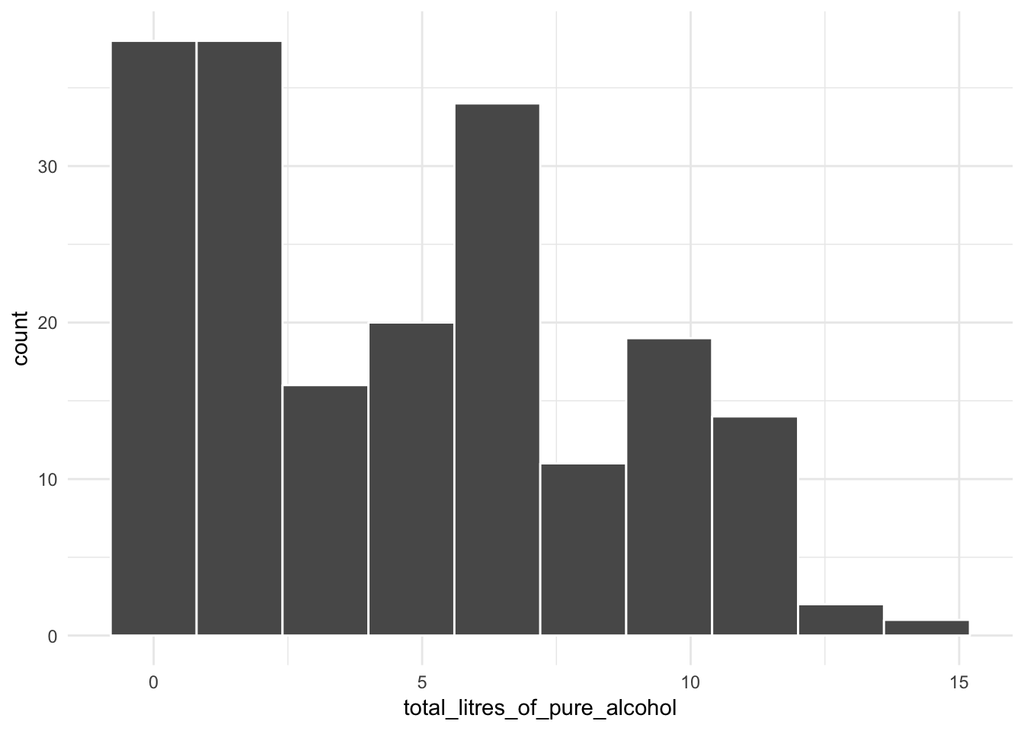

```r
ggplot(df, aes(x = total_litres_of_pure_alcohol)) +
  geom_histogram(bins = 10, color = "white") +
  theme_minimal()
```

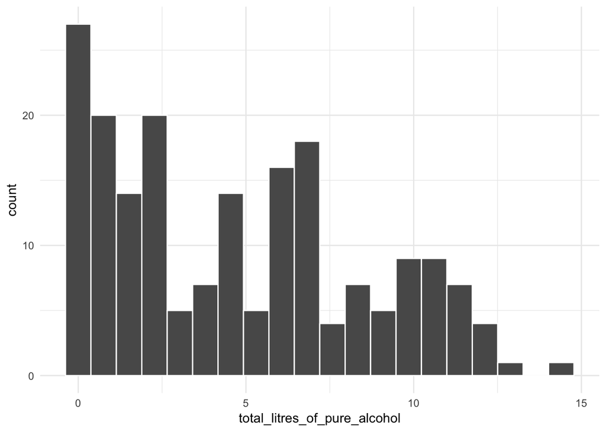

```r
ggplot(df, aes(x = total_litres_of_pure_alcohol)) +
  geom_histogram(bins = 20, color = "white") +
  theme_minimal()
```

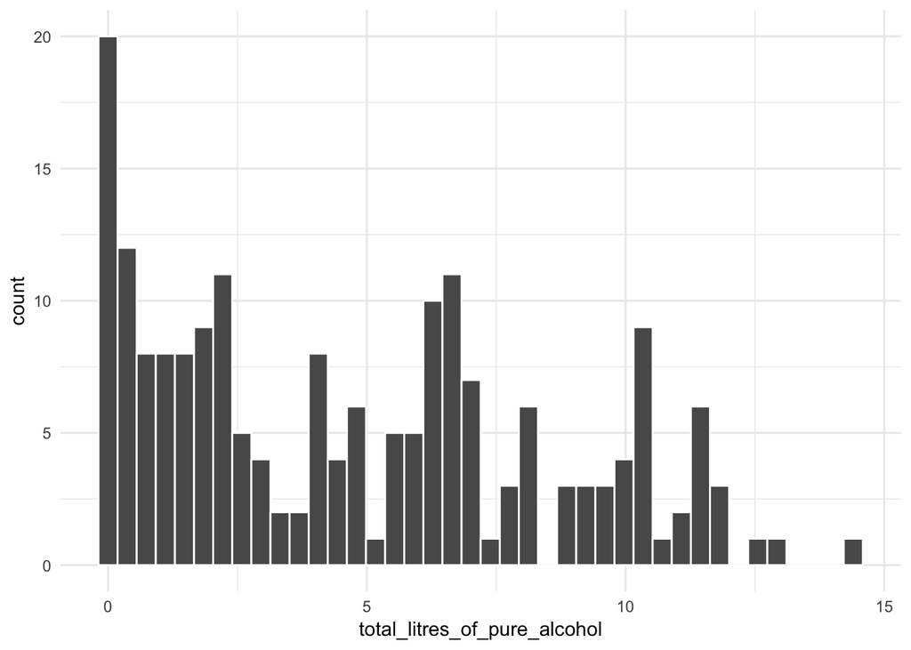

```r
ggplot(df, aes(x = total_litres_of_pure_alcohol)) +
  geom_histogram(bins = 40, color = "white") +
  theme_minimal()
```

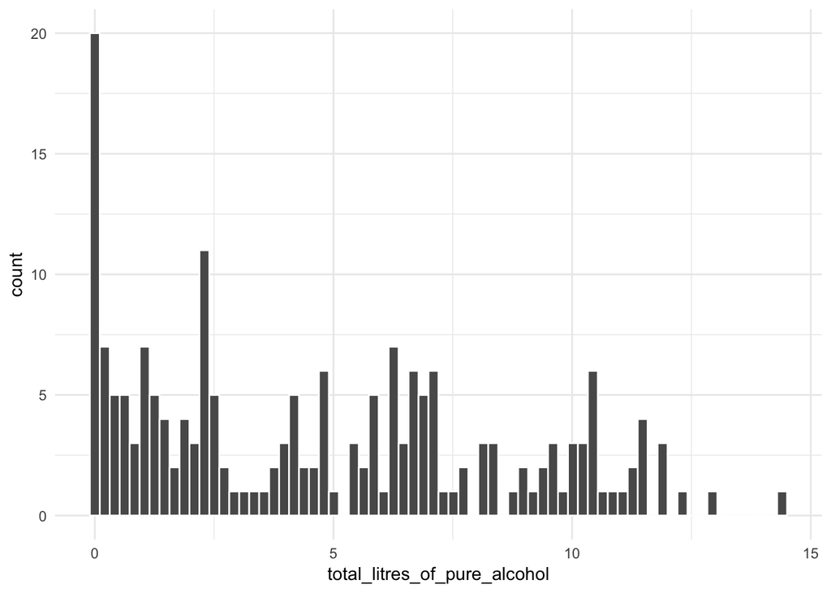

```r
ggplot(df, aes(x = total_litres_of_pure_alcohol)) +
  geom_histogram(bins = 70, color = "white") +
  theme_minimal()
```

I originally thought 40 or 50 bins was the right amount to show the distribution because it really captures the postive skew and the mode of alcohol consumed around 0. However, I then changed the color outline to white and saw the individual bars much better. I think the default bin count of 30 captures both the skew and mode just fine.

### Density plot

- compare the default bandwidth with a few other selections entered manually
- settle on a bandwidth selection, and justify why briefly in text

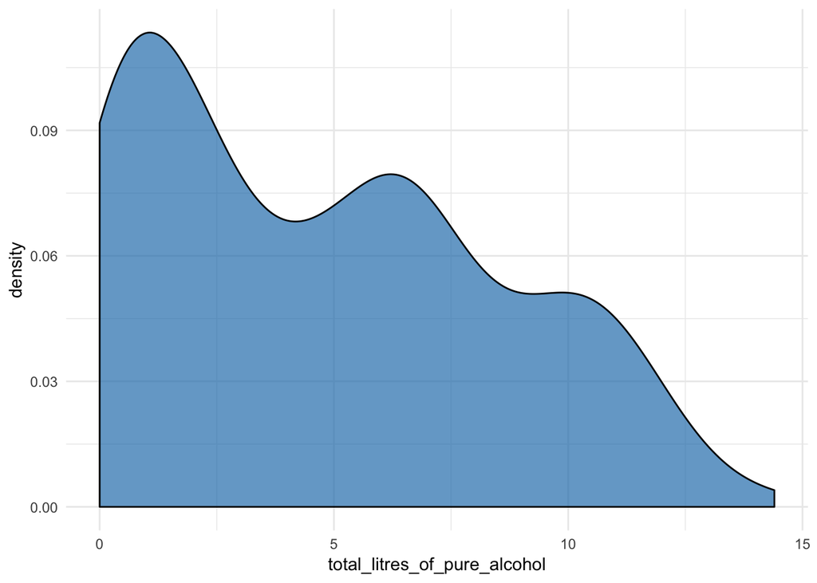

```r
ggplot(df, aes(x = total_litres_of_pure_alcohol)) +
  geom_density(fill = "#2980B9", alpha = .7) +
  theme_minimal()
```

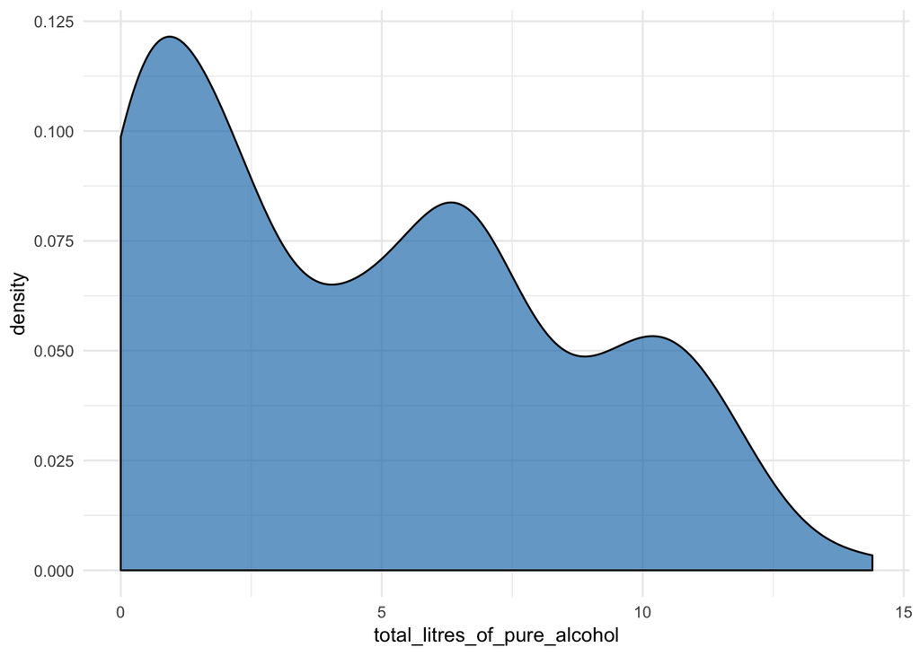

```r
ggplot(df, aes(x = total_litres_of_pure_alcohol)) +
  geom_density(fill = "#2980B9", alpha = .7, bw = 1) +
  theme_minimal()
```

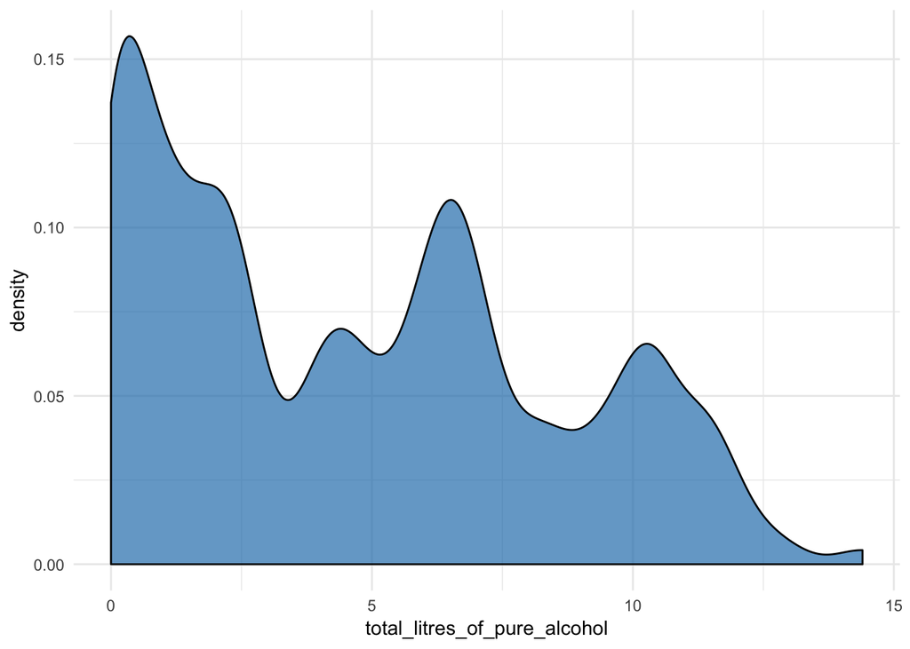

```r
ggplot(df, aes(x = total_litres_of_pure_alcohol)) +
  geom_density(fill = "#2980B9", alpha = .7, bw = .5) +
  theme_minimal()
```

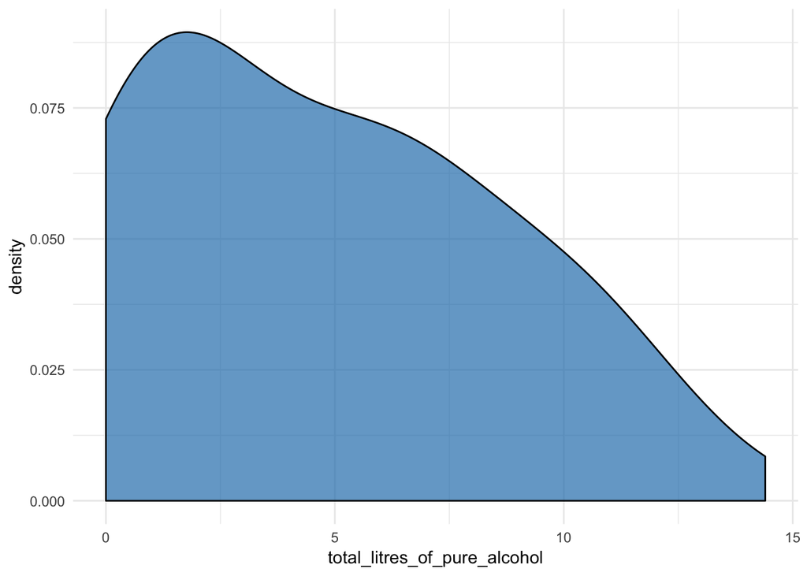

```r
ggplot(df, aes(x = total_litres_of_pure_alcohol)) +
  geom_density(fill = "#2980B9", alpha = .7, bw = 2) +
  theme_minimal()
```

The default bandwidth (was not sure how to find the default, but I figure its around 1) is perfect for capturing the positive skew and the mode around 0, as well as the few peaks that occcur above the mode.

## 3. Reorganize the data so you have a `type` and `servings` column.

```r
df_tidy <- df %>%
  gather(key = type, value = servings, 2:4)

# Check the order of the types when I factor so I know what order to label them
levels(factor(df_tidy$type))
```

```
## [1] "beer_servings"   "spirit_servings" "wine_servings"
```

```r
df_tidy$type <- factor(df_tidy$type, labels = c("Beer","Spirit","Wine"))
```

#### Evaluate the distribution of servings by type using at least three different methods. Provide a brief substantive conclusion.

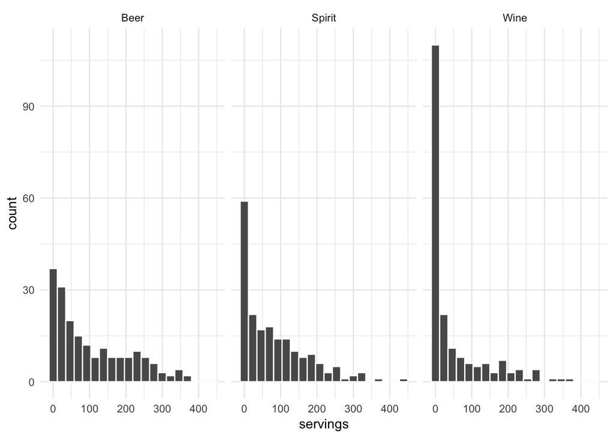

```r
ggplot(df_tidy, aes(x = servings)) +
  geom_histogram(color = "white", bins = 20) +
  theme_minimal() +
  facet_wrap(~type)
```

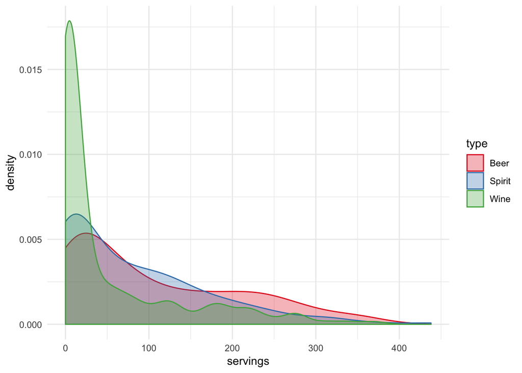

```r
ggplot(df_tidy, aes(x = servings, fill = type, color = type)) +
  geom_density(alpha = .3) +
  theme_minimal() +
  scale_fill_brewer(palette = "Set1") +
  scale_color_brewer(palette = "Set1")
```

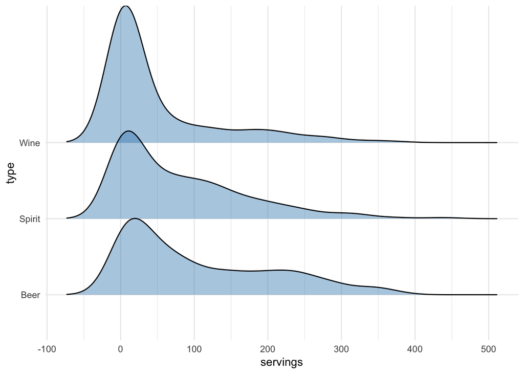

```r
ggplot(df_tidy, aes(x = servings, y = type)) +
  ggridges::geom_density_ridges(fill = "#2980B9", alpha = .4) +
  theme_minimal()
```

#### Reproduce the plot (servings by type per country)

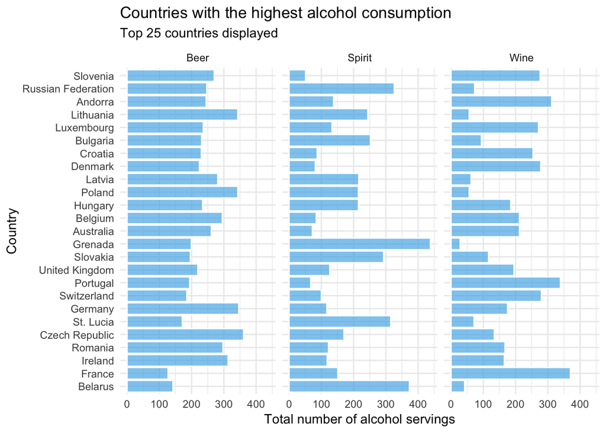

```r
# need to filter total alcohol consumption to top 25
df_top25 <- df %>%
  arrange(desc(total_litres_of_pure_alcohol)) %>%
  slice(1:25)

# put in tidy format
df_top25_tidy <- df_top25 %>%
  gather(key = type, value = servings, 2:4)

df_top25_tidy$type <- factor(df_top25_tidy$type, labels = c("Beer", "Spirit", "Wine"))


ggplot(df_top25_tidy, aes(x = fct_reorder(country, servings), y = servings)) +
  geom_bar(stat = "identity",
           fill = "#56B4E9", color = "white", alpha = .7) +
  coord_flip() +
  labs(title = "Countries with the highest alcohol consumption",
       subtitle = "Top 25 countries displayed",
       x = "Country",
       y = "Total number of alcohol servings") +
  theme_minimal() +
  facet_wrap(~type)
```